# Pisa Data Exploration

## Preliminary Wrangling

**PISA program overview**

The Programme for International Student Assessment (PISA) is an international assessment of the skills and knowledge of 15-year-old students; in addition, it provides information about a range of factors that contribute to the success of students, schools, and education systems. PISA is a collaborative effort among member countries of the Organisation for Economic Co-operation and Development (OECD).

PISA covers three domains — reading, mathematics, and science. Although each assessment includes questions from all three domains, the focus shifts. In 2000, the emphasis was on reading, with mathematics and science as minor domains. In 2003, mathematics was the major domain, and in 2006, it was science. In 2009, the focus was again reading, and in 2012, mathematics. In the assessment of 2015, the focus was science once again. The repetition of the assessments at regular intervals yields timely data that can be compared internationally and over time.

As PISA is an international assessment, it measures skills that are generally recognized as key outcomes of the educational process. Rather than testing on facts, the assessment focuses on young people near the end of compulsory schooling and their ability to use their knowledge and skills to meet real-life challenges.

**Participation**

International participation in PISA has grown steadily — from 32 countries/economies in 2000 to 41 in 2003, 57 in 2006, 65 in 2009, and 65 in 2012. In the latest PISA cycle, in 2015, there were 72 countries/economies participating. Canada has participated in PISA since its inception, through a partnership among CMEC, Employment and Social Development Canada, and Statistics Canada.

All 10 provinces have participated in each assessment. Approximately 20,000 Canadian students from about 1,000 schools have taken part in each PISA assessment in either English or French. Schools and the students within schools are selected randomly for participation. This large sample size allows results to be reported for each province, as well as for both the French- and English-language school systems in Nova Scotia, New Brunswick, Quebec, Ontario, Manitoba, Alberta, and British Columbia. Currently, Yukon, Northwest Territories, and Nunavut do not participate in PISA, nor do Indigenous students from band-operated schools.

The results are valid only on the pan-Canadian and provincial levels. No results are attributed to individual schools or students. PISA does not assess individual student achievement.

**The assessment**

In addition to two hours of direct assessment of reading, mathematics, and science, students in Canada complete a background questionnaire about themselves and their homes, about information and communication technology, and about their school experiences, work activities, and relationships with others. School principals complete a separate questionnaire.

In order to determine the content of the assessment, experts from OECD Member countries developed definitions for each domain, which guided the preparation of the testing instruments:

Reading literacy: The capacity to understand, use, and reflect on written texts in order to achieve one's goals and potential, develop knowledge, and participate in society. Mathematics literacy: The capacity to identify, understand, and engage in mathematics, and make well-founded judgments about the role that mathematics plays in the private, occupational, and social lives of constructive, concerned, and reflective citizens. Scientific literacy: The capacity to use scientific knowledge, identify questions, and draw evidence-based conclusions in order to understand and help make decisions about the natural world and the changes made to it through human activity.

One other domain was included in the PISA 2015 cycle, financial literacy, which was administered as an option in some countries, including some Canadian provinces. PISA 2015 was completely computerized.

**The benefits of PISA**

Canada invests significant public resources in the provision of elementary and secondary education, and Canadians are concerned about the quality of education provided by schools. The skills acquired by the end of secondary school are the essential foundation for further learning and for meeting the social and economic challenges of the future. PISA examines the level of achievement of 15-year-olds, providing an indication of the knowledge and skills they have acquired and their preparedness for continuing their studies or entering the workforce.

Results from PISA are valuable to educators, governments, social-policy analysts, and advocacy groups. Comparative information helps in the evaluation of the effectiveness of existing programs and practices, as well as in the understanding of the influences of socioeconomic and other factors on educational success.

**PISA results**

On an international level, Canada has performed very well in all of the PISA assessments. For example, in the 2018 assessment, Canadian 15-year-olds placed well above the OECD average and were among the top performers in reading. Of the 79 countries and economies participating in the assessment, only three— Beijing, Shanghai, Jiangsu, Zhejiang (B-S-J-Z) (China), Singapore, and Macao (China)—outperformed Canada.

source: https://www.cmec.ca/251/Programme_for_International_Student_Assessment_(PISA).html

```python
# import all packages and set plots to be embedded inline
import numpy as np
import pandas as pd
import matplotlib.pyplot as plt
import seaborn as sb

%matplotlib inline
```

> Load in your dataset and describe its properties through the questions below. Try and motivate your exploration goals through this section.

```python
# failed to read file as utf-8. changed to ISO-8859-1 instead.
df_pisa=pd.read_csv('pisa2012.csv', encoding = "ISO-8859-1")
```

```python
# read dataset dictionary
df_dict = pd.read_csv('pisadict2012.csv',encoding = "ISO-8859-1")
```

```python
df_pisa.info()
```

```
<class 'pandas.core.frame.DataFrame'>
RangeIndex: 485490 entries, 0 to 485489
Columns: 636 entries, Unnamed: 0 to VER_STU
dtypes: float64(250), int64(18), object(368)
memory usage: 2.3+ GB
```

```python
df_dict.head()
```

|  | CNT | Country code 3-character |
| --- | --- | --- |
| 0 | SUBNATIO | Adjudicated sub-region code 7-digit code (3-di... |
| 1 | STRATUM | Stratum ID 7-character (cnt + region ID + orig... |
| 2 | OECD | OECD country |
| 3 | NC | National Centre 6-digit Code |
| 4 | SCHOOLID | School ID 7-digit (region ID + stratum ID + 3-... |

```python
df_pisa.shape, df_dict.shape
```

```
((485490, 636), (634, 2))
```

```python
df_pisa['ST04Q01'].value_counts()
```

```
Female    245064
Male      240426
Name: ST04Q01, dtype: int64
```

```python
# Age counts
df_pisa['AGE'].value_counts()
```

```
15.58    42762
15.67    42353
15.75    41664
15.83    41402
15.92    41084
16.00    41049
15.42    40437
15.50    40291
16.08    39313
16.17    38356
15.33    28354
16.25    26139
15.25    11986
16.33    10183
15.17        1
Name: AGE, dtype: int64
```

```python
df_pisa['CNT'].value_counts()
```

```
Mexico                      33806
Italy                       31073
Spain                       25313
Canada                      21544
Brazil                      19204
                            ...
Florida (USA)                1896
Perm(Russian Federation)     1761
Massachusetts (USA)          1723
Connecticut (USA)            1697
Liechtenstein                 293
Name: CNT, Length: 68, dtype: int64
```

```python
# Unique countries
df_pisa['CNT'].nunique()
```

```
68
```

```python
df_pisa.dtypes
```

```
Unnamed: 0      int64
CNT            object
SUBNATIO        int64
STRATUM        object
OECD           object
               ...
W_FSTR80      float64
WVARSTRR        int64
VAR_UNIT        int64
SENWGT_STU    float64
VER_STU        object
Length: 636, dtype: object
```

```python
df_pisa.head()
```

|  | Unnamed: 0 | CNT | SUBNATIO | STRATUM | OECD | NC | SCHOOLID | STIDSTD | ST01Q01 | ST02Q01 | ... | W_FSTR75 | W_FSTR76 | W_FSTR77 | W_FSTR78 | W_FSTR79 | W_FSTR80 | WVARSTRR | VAR_UNIT | SENWGT_STU | VER_STU |
| --- | --- | --- | --- | --- | --- | --- | --- | --- | --- | --- | --- | --- | --- | --- | --- | --- | --- | --- | --- | --- | --- |
| 0 | 1 | Albania | 80000 | ALB0006 | Non-OECD | Albania | 1 | 1 | 10 | 1.0 | ... | 13.7954 | 13.9235 | 13.1249 | 13.1249 | 4.3389 | 13.0829 | 19 | 1 | 0.2098 | 22NOV13 |
| 1 | 2 | Albania | 80000 | ALB0006 | Non-OECD | Albania | 1 | 2 | 10 | 1.0 | ... | 13.7954 | 13.9235 | 13.1249 | 13.1249 | 4.3389 | 13.0829 | 19 | 1 | 0.2098 | 22NOV13 |
| 2 | 3 | Albania | 80000 | ALB0006 | Non-OECD | Albania | 1 | 3 | 9 | 1.0 | ... | 12.7307 | 12.7307 | 12.7307 | 12.7307 | 4.2436 | 12.7307 | 19 | 1 | 0.1999 | 22NOV13 |
| 3 | 4 | Albania | 80000 | ALB0006 | Non-OECD | Albania | 1 | 4 | 9 | 1.0 | ... | 12.7307 | 12.7307 | 12.7307 | 12.7307 | 4.2436 | 12.7307 | 19 | 1 | 0.1999 | 22NOV13 |
| 4 | 5 | Albania | 80000 | ALB0006 | Non-OECD | Albania | 1 | 5 | 9 | 1.0 | ... | 12.7307 | 12.7307 | 12.7307 | 12.7307 | 4.2436 | 12.7307 | 19 | 1 | 0.1999 | 22NOV13 |

5 rows × 636 columns

```python
df_pisa.NC.value_counts()
```

```
Mexico                       33806
Italy                        31073
Spain                        25313
Canada                       21544
Brazil                       19204
                             ...
New Zealand                   4291
Iceland                       3508
United Kingdom (Scotland)     2945
Perm (Russian Federation)     1761
Liechtenstein                  293
Name: NC, Length: 66, dtype: int64
```

```python
df_pisa.info(verbose=True, null_counts=True)
```

```
<class 'pandas.core.frame.DataFrame'>
RangeIndex: 485490 entries, 0 to 485489
Data columns (total 636 columns):
 #   Column       Non-Null Count   Dtype
---  ------       --------------   -----
 0   Unnamed: 0   485490 non-null  int64
 1   CNT          485490 non-null  object
 2   SUBNATIO     485490 non-null  int64
 3   STRATUM      485490 non-null  object
 4   OECD         485490 non-null  object
 5   NC           485490 non-null  object
 6   SCHOOLID     485490 non-null  int64
 7   STIDSTD      485490 non-null  int64
 8   ST01Q01      485490 non-null  int64
 9   ST02Q01      485438 non-null  float64
```

[output cut: 628 more lines]

## Data wrangling

During my analysis i will try answering the following quetions:

1. How will student from various countries perform in math, reading, and science cosidering mother, father education, work, availability of internet, and textbox?
2. Are there countries that perform better than others?
3. compare results based on gender?

```python
#Rename some of the columns to be more intiuitive and useful
cols=['CNT','STIDSTD','AGE','ST04Q01','ST11Q01', 'ST11Q02','ST13Q01','ST15Q01','ST17Q01','ST19Q01','ST26Q06','ST26Q10','PV1MATH','PV2MATH','PV3MATH','PV4MATH','PV5MATH','PV1READ','PV2READ','PV3READ','PV4READ','PV5READ','PV1SCIE','PV2SCIE','PV3SCIE','PV4SCIE','PV5SCIE']
df_pisa_clean = pd.read_csv('pisa2012.csv', usecols=cols, encoding = "ISO-8859-1")
```

```python
df_pisa_clean.info()
```

```
<class 'pandas.core.frame.DataFrame'>
RangeIndex: 485490 entries, 0 to 485489
Data columns (total 27 columns):
 #   Column   Non-Null Count   Dtype
---  ------   --------------   -----
 0   CNT      485490 non-null  object
 1   STIDSTD  485490 non-null  int64
 2   ST04Q01  485490 non-null  object
 3   ST11Q01  460559 non-null  object
 4   ST11Q02  441036 non-null  object
 5   ST13Q01  457979 non-null  object
 6   ST15Q01  467751 non-null  object
 7   ST17Q01  443261 non-null  object
 8   ST19Q01  451410 non-null  object
 9   ST26Q06  473182 non-null  object
```

[output cut: 19 more lines]

## fill columns with nan values as below

```python
#fillna with 'unknown for nan values of mother at home: ST11Q01 & father at home ST11Q02
#mother at home with unknown
df_pisa_clean['ST11Q01'].fillna('unknown', inplace=True)
# fillna father at home with unknjown
df_pisa_clean['ST11Q02'].fillna('unknown', inplace=True)
#mother highest schooling
df_pisa_clean['ST13Q01'].fillna('unknown', inplace=True)
#mother current job  with unknjown
df_pisa_clean['ST15Q01'].fillna('unknown', inplace=True)
#father highest schooling  with unknjown
df_pisa_clean['ST17Q01'].fillna('unknown', inplace=True)
#father current job  with unknjown
df_pisa_clean['ST19Q01'].fillna('unknown', inplace=True)
#internet  with unknjown
df_pisa_clean['ST26Q06'].fillna('unknown', inplace=True)
#testbook  with unknjown
df_pisa_clean['ST26Q10'].fillna('unknown', inplace=True)
#age with mean age
mean=df_pisa_clean['AGE'].mean()
df_pisa_clean['AGE'].fillna(mean, inplace=True)
```

```python
df_pisa_clean.info()
```

```
<class 'pandas.core.frame.DataFrame'>
RangeIndex: 485490 entries, 0 to 485489
Data columns (total 27 columns):
 #   Column   Non-Null Count   Dtype
---  ------   --------------   -----
 0   CNT      485490 non-null  object
 1   STIDSTD  485490 non-null  int64
 2   ST04Q01  485490 non-null  object
 3   ST11Q01  485490 non-null  object
 4   ST11Q02  485490 non-null  object
 5   ST13Q01  485490 non-null  object
 6   ST15Q01  485490 non-null  object
 7   ST17Q01  485490 non-null  object
 8   ST19Q01  485490 non-null  object
 9   ST26Q06  485490 non-null  object
```

[output cut: 19 more lines]

```python
df_pisa_clean['ST11Q02'].value_counts()
```

```
Yes        372161
No          68875
unknown     44454
Name: ST11Q02, dtype: int64
```

## Rename columns to be more intuitive and easy to handle

```python
df_pisa_clean.rename(columns={'CNT': 'country', 'STIDSTD': 'student_id', 'AGE':'age','ST04Q01':'gender',
                              'ST11Q01':'mother_at_home','ST11Q02':'father_at_home',
                              'ST13Q01':'mother_grade', 'ST15Q01':'mother_job','ST17Q01':'father_grade',
                              'ST19Q01':'father_job','ST26Q06':'internet','ST26Q10':'textbook'},inplace=True)
```

```python
df_pisa_clean.info()
```

```
<class 'pandas.core.frame.DataFrame'>
RangeIndex: 485490 entries, 0 to 485489
Data columns (total 27 columns):
 #   Column          Non-Null Count   Dtype
---  ------          --------------   -----
 0   country         485490 non-null  object
 1   student_id      485490 non-null  int64
 2   gender          485490 non-null  object
 3   mother_at_home  485490 non-null  object
 4   father_at_home  485490 non-null  object
 5   mother_grade    485490 non-null  object
 6   mother_job      485490 non-null  object
 7   father_grade    485490 non-null  object
 8   father_job      485490 non-null  object
 9   internet        485490 non-null  object
```

[output cut: 19 more lines]

```python
# calculate mean value for math, reading, science
# add a new column for total of means
df_pisa_clean['math']=(df_pisa_clean['PV1MATH']+df_pisa_clean['PV2MATH']+df_pisa_clean['PV3MATH']+df_pisa_clean['PV4MATH']+df_pisa_clean['PV5MATH'])/5
df_pisa_clean['reading']=(df_pisa_clean['PV1READ']+df_pisa_clean['PV2READ']+df_pisa_clean['PV3READ']+df_pisa_clean['PV4READ']+df_pisa_clean['PV5READ'])/5
df_pisa_clean['science']=(df_pisa_clean['PV1SCIE']+df_pisa_clean['PV2SCIE']+df_pisa_clean['PV3SCIE']+df_pisa_clean['PV4SCIE']+df_pisa_clean['PV5SCIE'])/5
df_pisa_clean['total']=(df_pisa_clean['math']+df_pisa_clean['reading']+df_pisa_clean['science'])/3
```

```python
# since we are used the average value for each of Math, reading and science, no need to keep the old columns.
df_pisa_clean.drop(columns=['PV1MATH','PV2MATH','PV3MATH','PV4MATH','PV5MATH',
                           'PV1READ','PV2READ','PV3READ','PV4READ','PV5READ',
                           'PV1SCIE','PV2SCIE','PV3SCIE','PV4SCIE','PV5SCIE'],inplace=True)
```

```python
df_pisa_clean.info()
```

```
<class 'pandas.core.frame.DataFrame'>
RangeIndex: 485490 entries, 0 to 485489
Data columns (total 16 columns):
 #   Column          Non-Null Count   Dtype
---  ------          --------------   -----
 0   country         485490 non-null  object
 1   student_id      485490 non-null  int64
 2   gender          485490 non-null  object
 3   mother_at_home  485490 non-null  object
 4   father_at_home  485490 non-null  object
 5   mother_grade    485490 non-null  object
 6   mother_job      485490 non-null  object
 7   father_grade    485490 non-null  object
 8   father_job      485490 non-null  object
 9   internet        485490 non-null  object
 10  textbook        485490 non-null  object
 11  age             485490 non-null  float64
 12  math            485490 non-null  float64
 13  reading         485490 non-null  float64
 14  science         485490 non-null  float64
 15  total           485490 non-null  float64
dtypes: float64(5), int64(1), object(10)
memory usage: 59.3+ MB
```

```python
df_pisa_clean['mother_grade'].value_counts()
```

```
<ISCED level 3A>                         236993
<ISCED level 3B, 3C>                      83048
<ISCED level 2>                           82614
<ISCED level 1>                           36556
unknown                                   27511
She did not complete <ISCED level 1>      18768
Name: mother_grade, dtype: int64
```

```python
df_pisa_clean['father_grade'].value_counts()
```

```
<ISCED level 3A>                        215280
<ISCED level 3B, 3C>                     91179
<ISCED level 2>                          84329
unknown                                  42229
<ISCED level 1>                          35938
He did not complete <ISCED level 1>      16535
Name: father_grade, dtype: int64
```

```python
# replace values to be less wordy
df_pisa_clean['mother_grade'].replace({'<ISCED level 3A> ':'ISCED 3A','<ISCED level 3B, 3C> ': 'ISCED 3B-3C',
                                       '<ISCED level 2> ':'ISCED 2', '<ISCED level 1> ':'ISCED 1',
                                       'She did not complete <ISCED level 1> ':'incomplete ISCED 1'}, inplace=True)

df_pisa_clean['father_grade'].replace({'<ISCED level 3A> ':'ISCED 3A','<ISCED level 3B, 3C> ': 'ISCED 3B-3C',
                                       '<ISCED level 2> ':'ISCED 2', '<ISCED level 1> ':'ISCED 1',
                                       'He did not complete <ISCED level 1> ':'incomplete ISCED 1'}, inplace=True)
```

```python
df_pisa_clean['mother_grade'].value_counts()
```

```
ISCED 3A              236993
ISCED 3B-3C            83048
ISCED 2                82614
ISCED 1                36556
unknown                27511
incomplete ISCED 1     18768
Name: mother_grade, dtype: int64
```

```python
df_pisa_clean['father_grade'].value_counts()
```

```
ISCED 3A              215280
ISCED 3B-3C            91179
ISCED 2                84329
unknown                42229
ISCED 1                35938
incomplete ISCED 1     16535
Name: father_grade, dtype: int64
```

```python
df_pisa_clean['internet'].value_counts()
```

```
Yes        402040
No          71142
unknown     12308
Name: internet, dtype: int64
```

```python
df_pisa_clean['textbook'].value_counts()
```

```
Yes        389408
No          81834
unknown     14248
Name: textbook, dtype: int64
```

```python
df_pisa_clean['father_job'].value_counts()
```

```
Working full-time <for pay>           339697
Working part-time <for pay>            49503
Other (e.g. home duties, retired)      40588
unknown                                34080
Not working, but looking for a job     21622
Name: father_job, dtype: int64
```

```python
df_pisa_clean['mother_job'].value_counts()
```

```
Working full-time <for pay>            219095
Other (e.g. home duties, retired)      138841
Working part-time <for pay>             78237
Not working, but looking for a job      31578
unknown                                 17739
Name: mother_job, dtype: int64
```

```python
# replace values to be less wordy
df_pisa_clean['mother_job'].replace({'Working full-time <for pay> ' : 'full-time',
                                     'Other (e.g. home duties, retired) ' : 'others',
                                     'Working part-time <for pay>' : 'part-time',
                                     'Not working, but looking for a job ' : 'unemployed'}, inplace=True)

df_pisa_clean['father_job'].replace({'Working full-time <for pay> ' : 'full-time',
                                     'Other (e.g. home duties, retired) ' : 'others',
                                     'Working part-time <for pay>' : 'part-time',
                                     'Not working, but looking for a job' : 'unemployed'}, inplace=True)
```

```python
df_pisa_clean['mother_job'].value_counts()
```

[output not shown]

```python
df_pisa_clean['father_job'].value_counts()
```

[output not shown]

```python
# grades is an ordinal category, assuming unknown as the lowest, and ISCED 3B-3C is the max
grades_category=['unknown','incomplete ISCED 1','ISCED 1','ISCED 2','ISCED 3A','ISCED 3B-3C',]
grades=pd.api.types.CategoricalDtype(ordered=True,categories=grades_category)
df_pisa_clean['mother_grade']=df_pisa_clean['mother_grade'].astype(grades)
df_pisa_clean['father_grade']=df_pisa_clean['father_grade'].astype(grades)
```

```python
# job category is more a nominal datatype, there is not sequence we can use to say this is higher than the other.

job_category=['unknown', 'unemployed','part-time', 'full-time', 'others']
jobs=pd.api.types.CategoricalDtype(ordered=False,categories=job_category)
df_pisa_clean['mother_job']=df_pisa_clean['mother_job'].astype(jobs)
df_pisa_clean['father_job']=df_pisa_clean['father_job'].astype(jobs)
```

```python
# modify type to category for internet, textbook, father_at_home, mother_at_home

df_pisa_clean = df_pisa_clean.astype({'internet':'category', 'textbook':'category',
                                      'gender':'category','mother_at_home':'category','father_at_home':'category'})
```

```python
df_pisa_clean.info()
```

```
<class 'pandas.core.frame.DataFrame'>
RangeIndex: 485490 entries, 0 to 485489
Data columns (total 16 columns):
 #   Column          Non-Null Count   Dtype
---  ------          --------------   -----
 0   country         485490 non-null  object
 1   student_id      485490 non-null  int64
 2   gender          485490 non-null  category
 3   mother_at_home  485490 non-null  category
 4   father_at_home  485490 non-null  category
 5   mother_grade    485490 non-null  category
 6   mother_job      485490 non-null  category
 7   father_grade    485490 non-null  category
 8   father_job      485490 non-null  category
 9   internet        485490 non-null  category
 10  textbook        485490 non-null  category
 11  age             485490 non-null  float64
 12  math            485490 non-null  float64
 13  reading         485490 non-null  float64
 14  science         485490 non-null  float64
 15  total           485490 non-null  float64
dtypes: category(9), float64(5), int64(1), object(1)
memory usage: 30.1+ MB
```

```python
df_pisa_clean.head()
```

|  | country | student_id | gender | mother_at_home | father_at_home | mother_grade | mother_job | father_grade | father_job | internet | textbook | age | math | reading | science | total |
| --- | --- | --- | --- | --- | --- | --- | --- | --- | --- | --- | --- | --- | --- | --- | --- | --- |
| 0 | Albania | 1 | Female | Yes | Yes | ISCED 3A | others | ISCED 3A | part-time | No | Yes | 16.17 | 366.18634 | 261.01424 | 371.91348 | 333.038020 |
| 1 | Albania | 2 | Female | Yes | Yes | ISCED 3A | full-time | ISCED 3A | full-time | Yes | Yes | 16.17 | 470.56396 | 384.68832 | 478.12382 | 444.458700 |
| 2 | Albania | 3 | Female | Yes | Yes | ISCED 3B-3C | full-time | ISCED 3A | full-time | Yes | Yes | 15.58 | 505.53824 | 405.18154 | 486.60946 | 465.776413 |
| 3 | Albania | 4 | Female | Yes | Yes | ISCED 3B-3C | full-time | ISCED 3A | full-time | Yes | Yes | 15.67 | 449.45476 | 477.46376 | 453.97240 | 460.296973 |
| 4 | Albania | 5 | Female | Yes | Yes | incomplete ISCED 1 | part-time | ISCED 3B-3C | part-time | Yes | Yes | 15.50 | 385.50398 | 256.01010 | 367.15778 | 336.223953 |

```python
# Saving clearn dataset to local file
df_pisa_clean.to_csv('df_pisa_clean.csv', index=False)
```

### What is the structure of your dataset?

> the data structure is very wide, has consideration for many many cases and factors such as job of the father, job for mother, every aspect of living details like if child got a separte room, type of electornic devices, and so much more. Such details seems to have purposes beyod the objectives of the project, and need deep analysis for optimal use, and probably other aspect which i am not aware of.

### What is/are the main feature(s) of interest in your dataset?

> Main aspect of my interest is math, science, and reading. this is where i will focus my analysis on.

### What features in the dataset do you think will help support your investigation into your feature(s) of interest?

> Math, science, and reading each has five separate scores. i have used the mean for each as a separate column. this new value will be used by focus my analysis on.

## Univariate Exploration

> In this section, investigate distributions of individual variables. If you see unusual points or outliers, take a deeper look to clean things up and prepare yourself to look at relationships between variables.

> Make sure that, after every plot or related series of plots, that you include a Markdown cell with comments about what you observed, and what you plan on investigating next.

```python
df_pisa_clean[['math','reading','science','total']].describe()
```

|  | math | reading | science | total |
| --- | --- | --- | --- | --- |
| count | 485490.000000 | 485490.000000 | 485490.000000 | 485490.000000 |
| mean | 469.651234 | 472.006964 | 475.808094 | 472.488764 |
| std | 100.786610 | 98.863310 | 97.998470 | 96.036271 |
| min | 54.767080 | 6.445400 | 25.158540 | 77.114593 |
| 25% | 396.019620 | 405.044200 | 405.762800 | 403.992595 |
| 50% | 465.734520 | 475.477980 | 475.512860 | 472.046460 |
| 75% | 540.123060 | 542.831195 | 546.381920 | 541.455700 |
| max | 903.107960 | 849.359740 | 857.832900 | 826.592027 |

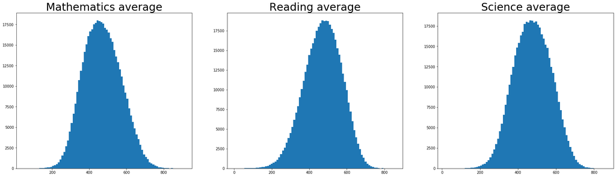

```python
math_bins=np.arange(50,df_pisa_clean['math'].max()+10,10)
reading_bins=np.arange(5,df_pisa_clean['reading'].max()+10,10)
science_bins=np.arange(20,df_pisa_clean['science'].max()+10,10)

plt.figure(figsize=(30,8))
plt.subplot(1, 3, 1)
plt.hist(df_pisa_clean['math'],bins=math_bins);
plt.title('Mathematics average',fontsize=30)


plt.subplot(1, 3, 2)
plt.hist(df_pisa_clean['reading'],bins=reading_bins);
plt.title('Reading average',fontsize=30)


plt.subplot(1, 3, 3)
plt.hist(df_pisa_clean['science'],bins=science_bins);
plt.title('Science average',fontsize=30);
```

1. All seems like normal ditribution
2. further investigation needs to be done considering country, and gender as well as other categorica variables like internet, mother/father grade, job, etc..

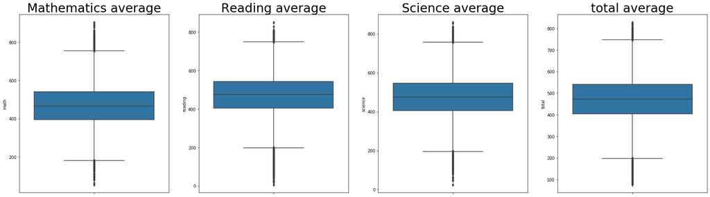

```python
plt.figure(figsize=(30,8))
plt.subplot(1, 4, 1)
sb.boxplot(y=df_pisa_clean['math'])
plt.title('Mathematics average',fontsize=30)


plt.subplot(1, 4, 2)
sb.boxplot(y=df_pisa_clean['reading'])
plt.title('Reading average',fontsize=30)


plt.subplot(1, 4, 3)
sb.boxplot(y=df_pisa_clean['science'])
plt.title('Science average',fontsize=30);

plt.subplot(1, 4, 4)
sb.boxplot(y=df_pisa_clean['total'])
plt.title('total average',fontsize=30);
```

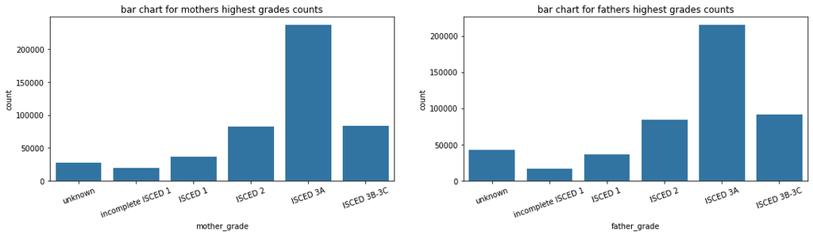

```python
color=sb.color_palette()[0]
plt.figure(figsize=(18,4))

plt.subplot(1, 2, 1)
sb.countplot(data=df_pisa_clean,x='mother_grade',color=color)
plt.title('bar chart for mothers highest grades counts')
plt.xticks(rotation=20)

plt.subplot(1, 2, 2)
sb.countplot(data=df_pisa_clean,x='father_grade',color=color)
plt.title('bar chart for fathers highest grades counts')
plt.xticks(rotation=20)
```

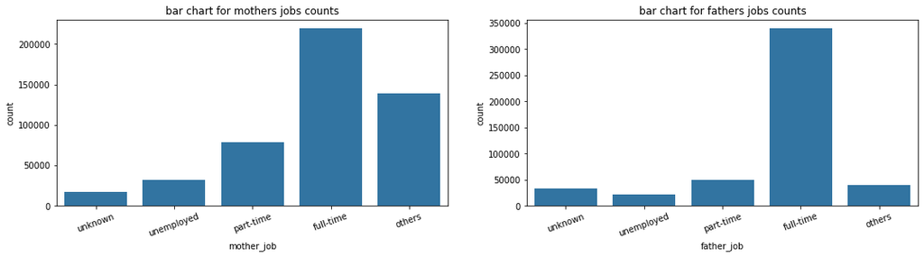

```python
color=sb.color_palette()[0]
plt.figure(figsize=(18,4))

plt.subplot(1, 2, 1)
sb.countplot(data=df_pisa_clean,x='mother_job',color=color);
plt.title('bar chart for mothers jobs counts');
plt.xticks(rotation=20);

plt.subplot(1, 2, 2)
sb.countplot(data=df_pisa_clean,x='father_job',color=color);
plt.title('bar chart for fathers jobs counts');
plt.xticks(rotation=20);
```

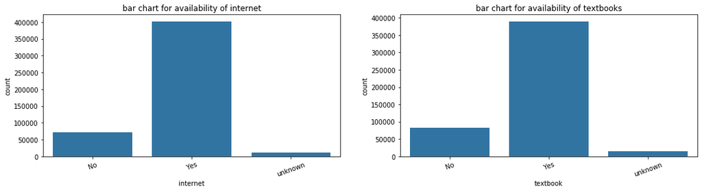

```python
color=sb.color_palette()[0]
plt.figure(figsize=(18,4))

plt.subplot(1, 2, 1)
sb.countplot(data=df_pisa_clean,x='internet',color=color);
plt.title('bar chart for availability of internet');
plt.xticks(rotation=20);

plt.subplot(1, 2, 2)
sb.countplot(data=df_pisa_clean,x='textbook',color=color);
plt.title('bar chart for availability of textbooks');
plt.xticks(rotation=20);
```

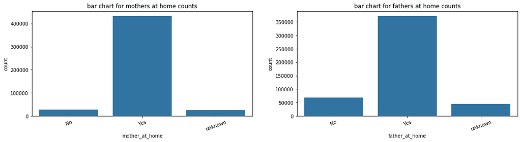

```python
color=sb.color_palette()[0]
plt.figure(figsize=(18,4))

plt.subplot(1, 2, 1)
sb.countplot(data=df_pisa_clean,x='mother_at_home',color=color);
plt.title('bar chart for mothers at home counts');
plt.xticks(rotation=20);

plt.subplot(1, 2, 2)
sb.countplot(data=df_pisa_clean,x='father_at_home',color=color);
plt.title('bar chart for fathers at home counts');
plt.xticks(rotation=20);
```

1. using boxplot we notice big range of outliars, this is also clear when we used the describe method for the three columns (math, reading, and science)
2. math average seems to have the lowest median
3. conclusion, we need to investigate data using bivariant exploration on country, gender, age, and other variables

### Discuss the distribution(s) of your variable(s) of interest. Were there any unusual points? Did you need to perform any transformations?

> using the average value along gives normal distribution, but there are many outliars which indicates variations based on other factors

### Of the features you investigated, were there any unusual distributions? Did you perform any operations on the data to tidy, adjust, or change the form of the data? If so, why did you do this?

> i used the mean for the three most important features math, reading, science to analyze the data

## Bivariate Exploration

> In this section, investigate relationships between pairs of variables in your data. Make sure the variables that you cover here have been introduced in some fashion in the previous section (univariate exploration).

#### check for math, reading, science average based on counties to find any relation between top permers and countries

```python
df_pisa_countries = df_pisa_clean.groupby('country')[['math','reading','science','total']].mean()
```

```python
df_pisa_countries.sort_values(by='total', ascending=False).head(10)
```

| country | math | reading | science | total |
| --- | --- | --- | --- | --- |
| China-Shanghai | 611.438933 | 568.629233 | 579.556540 | 586.541569 |
| Hong Kong-China | 561.052123 | 544.521735 | 554.986433 | 553.520097 |
| Singapore | 568.546974 | 537.742138 | 546.822920 | 551.037344 |
| Korea | 553.752034 | 535.805221 | 537.831998 | 542.463084 |
| Japan | 535.925248 | 537.722484 | 546.413455 | 540.020395 |
| Chinese Taipei | 558.312010 | 522.185472 | 522.356935 | 534.284806 |
| Liechtenstein | 538.886608 | 518.275718 | 527.598522 | 528.253616 |
| Estonia | 522.340803 | 518.208090 | 543.241849 | 527.930247 |
| Poland | 520.522589 | 520.763584 | 528.245169 | 523.177114 |
| Macao-China | 538.319791 | 509.095969 | 520.690411 | 522.702057 |

```python
df_pisa_countries.sort_values(by='total', ascending=False).tail(10)
```

| country | math | reading | science | total |
| --- | --- | --- | --- | --- |
| Montenegro | 406.728296 | 419.983824 | 408.197858 | 411.636659 |
| Argentina | 395.635711 | 403.596060 | 410.478404 | 403.236725 |
| Colombia | 385.972409 | 414.221547 | 408.862431 | 403.018796 |
| Albania | 394.878912 | 396.250245 | 398.916529 | 396.681895 |
| Tunisia | 387.434260 | 403.614273 | 397.831316 | 396.293283 |
| Jordan | 382.739077 | 396.514701 | 404.795878 | 394.683219 |
| Brazil | 382.547146 | 400.421704 | 395.513221 | 392.827357 |
| Indonesia | 375.621968 | 397.114815 | 382.744804 | 385.160529 |
| Qatar | 376.339232 | 387.407142 | 383.531664 | 382.426012 |
| Peru | 367.859676 | 384.453116 | 373.440303 | 375.251032 |

```
(300, 700)
```

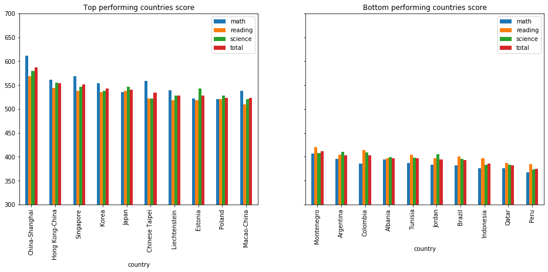

```python
f,axes = plt.subplots(1,2, figsize=(16,6), sharey=True)
df_pisa_countries.sort_values(by='total', ascending=False).head(10).plot(kind='bar',ax=axes[0])
df_pisa_countries.sort_values(by='total', ascending=False).tail(10).plot(kind='bar',ax=axes[1]);
axes[0].set_title('Top performing countries score');
axes[1].set_title('Bottom performing countries score');
plt.ylim(300,700)
```

1. Around 7 out of 10 top performer countries are in Far east, remaining 3 in Europe
2. Countries coming at the bottom mainly from South America and middle east, Peru coming at last place.
3. more investigation on total average

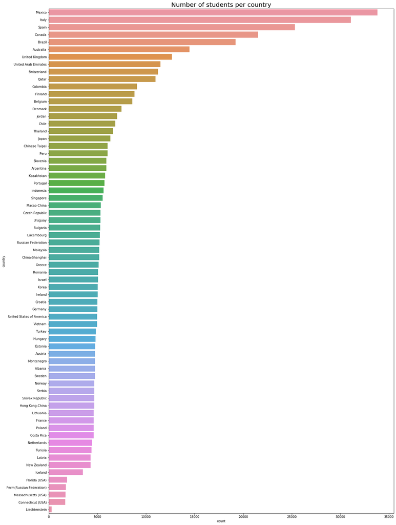

```python
order= df_pisa_clean['country'].value_counts().index
plt.figure(figsize=[20,30])
sb.countplot(data=df_pisa_clean,y='country',order=order)
plt.title('Number of students per country',size=20);
```

```python
df_pisa_gender = df_pisa_clean.groupby('gender')[['math','reading','science','total']].mean().reset_index()
df_pisa_gender
```

|  | gender | math | reading | science | total |
| --- | --- | --- | --- | --- | --- |
| 0 | Female | 464.060962 | 489.719710 | 475.348653 | 476.376442 |
| 1 | Male | 475.349347 | 453.952526 | 476.276398 | 468.526090 |

```python
489.719710-453.95252
```

```
35.76719000000003
```

```python
df_pisa_gender_melt = pd.melt(df_pisa_gender, id_vars=['gender'])
df_pisa_gender_melt
```

|  | gender | variable | value |
| --- | --- | --- | --- |
| 0 | Female | math | 464.060962 |
| 1 | Male | math | 475.349347 |
| 2 | Female | reading | 489.719710 |
| 3 | Male | reading | 453.952526 |
| 4 | Female | science | 475.348653 |
| 5 | Male | science | 476.276398 |
| 6 | Female | total | 476.376442 |
| 7 | Male | total | 468.526090 |

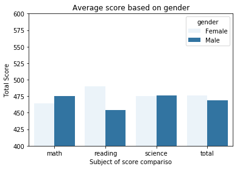

```python
sb.barplot(data=df_pisa_gender_melt, x="variable",y="value",hue="gender", color=sb.color_palette()[0])

plt.title('Average score based on gender')
plt.xlabel('Subject of score compariso')
plt.ylabel('Total Score')
plt.ylim(400, 600);
```

```python
df_pisa_internet = df_pisa_clean.groupby('internet')[['math','reading','science','total']].mean().reset_index()
df_pisa_internet
```

|  | internet | math | reading | science | total |
| --- | --- | --- | --- | --- | --- |
| 0 | No | 400.018756 | 408.247075 | 409.686776 | 405.984202 |
| 1 | Yes | 484.814701 | 486.403139 | 490.411081 | 487.209640 |
| 2 | unknown | 376.823281 | 370.298152 | 380.993168 | 376.038200 |

```python
df_pisa_internet_melt = pd.melt(df_pisa_internet, id_vars=['internet'])
df_pisa_internet_melt
```

|  | internet | variable | value |
| --- | --- | --- | --- |
| 0 | No | math | 400.018756 |
| 1 | Yes | math | 484.814701 |
| 2 | unknown | math | 376.823281 |
| 3 | No | reading | 408.247075 |
| 4 | Yes | reading | 486.403139 |
| 5 | unknown | reading | 370.298152 |
| 6 | No | science | 409.686776 |
| 7 | Yes | science | 490.411081 |
| 8 | unknown | science | 380.993168 |
| 9 | No | total | 405.984202 |
| 10 | Yes | total | 487.209640 |
| 11 | unknown | total | 376.038200 |

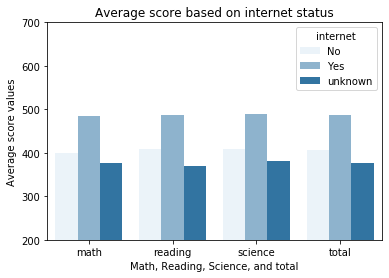

```python
sb.barplot(data=df_pisa_internet_melt, x="variable",y="value",hue="internet",color=sb.color_palette()[0])
plt.ylim(200,700)
plt.xlabel('Math, Reading, Science, and total');
plt.ylabel('Average score values');
plt.title('Average score based on internet status');
```

```python
df_top_5_countries=df_pisa_clean.groupby('country').mean()[['math','reading','science','total']].sort_values(by='total', ascending=False).head(5)
top_countries_list=df_top_5_countries.index.to_list()
df_top_5_countries=df_top_5_countries.reset_index()
df_top_5_countries=df_pisa_clean.loc[df_pisa_clean['country'].isin(top_countries_list)]
df_top_5_countries['country'].value_counts()
```

```
Japan              6351
Singapore          5546
China-Shanghai     5177
Korea              5033
Hong Kong-China    4670
Name: country, dtype: int64
```

```python
def plot_facegrid_hist(datafram, col, bins):
    g = sb.FacetGrid(data = datafram, col = col,col_wrap=3,sharey=True)
    g.map(plt.hist, "total",bins=bins)
```

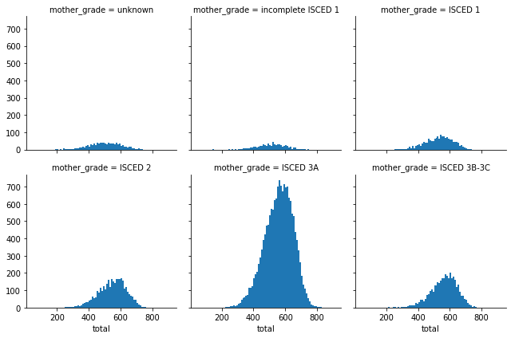

```python
plot_facegrid_hist(df_top_5_countries, 'mother_grade', math_bins)
```

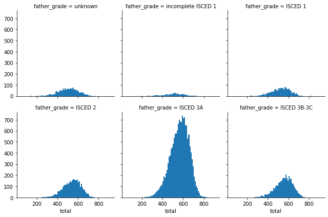

```python
plot_facegrid_hist(df_top_5_countries, 'father_grade', math_bins)
```

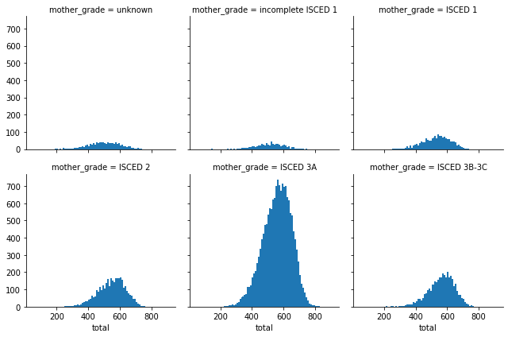

```python
plot_facegrid_hist(df_top_5_countries, 'mother_grade', math_bins)
```

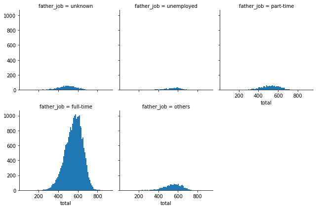

```python
plot_facegrid_hist(df_top_5_countries, 'father_job', math_bins)
```

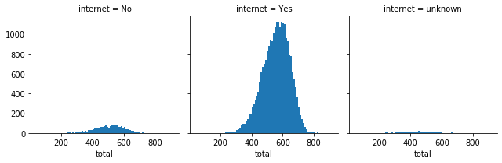

```python
plot_facegrid_hist(df_top_5_countries, 'internet', math_bins)
```

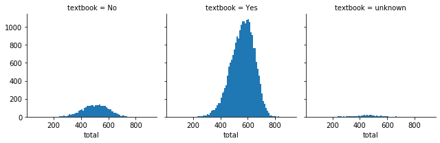

```python
plot_facegrid_hist(df_top_5_countries, 'textbook', math_bins)
```

1. Data shows that most of the students have parents (mother / father) that finished 'ISCED level 3A' level
2. same for full time working mom / dads
3. most people have internet, and textbook

### Talk about some of the relationships you observed in this part of the investigation. How did the feature(s) of interest vary with other features in the dataset?

1. the internet had a huge impact on the scores compared with student who didn't have access to internet

### Did you observe any interesting relationships between the other features (not the main feature(s) of interest)?

1. Females in generals had better scores specially in reading
2. Around 7 out of 10 top performer countries are in Far east, remaining 3 in Europe
3. low performing countries range from South America & middle east, Peru at last place.

## Multivariate Exploration

> Create plots of three or more variables to investigate your data even further. Make sure that your investigations are justified, and follow from your work in the previous sections.

```python
df_pisa_clean_copy=df_pisa_clean.copy()
```

```python
df_pisa_clean_copy.drop(columns=['total'], inplace=True)
```

```python
df_pisa_clean_melt = df_pisa_clean_copy.melt(id_vars=['country','student_id','gender','mother_at_home','father_at_home','mother_grade','father_grade',
                           'father_job','mother_job','internet','textbook','age'],
                   var_name='material',value_name='score')
```

```python
df_pisa_clean_melt.info()
```

```
<class 'pandas.core.frame.DataFrame'>
RangeIndex: 1456470 entries, 0 to 1456469
Data columns (total 14 columns):
 #   Column          Non-Null Count    Dtype
---  ------          --------------    -----
 0   country         1456470 non-null  object
 1   student_id      1456470 non-null  int64
 2   gender          1456470 non-null  category
 3   mother_at_home  1456470 non-null  category
 4   father_at_home  1456470 non-null  category
 5   mother_grade    1456470 non-null  category
 6   father_grade    1456470 non-null  category
 7   father_job      1456470 non-null  category
 8   mother_job      1456470 non-null  category
 9   internet        1456470 non-null  category
 10  textbook        1456470 non-null  category
 11  age             1456470 non-null  float64
 12  material        1456470 non-null  object
 13  score           1456470 non-null  float64
dtypes: category(9), float64(2), int64(1), object(2)
memory usage: 68.1+ MB
```

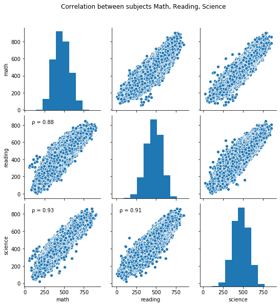

```python
#source: https://stackoverflow.com/questions/30942577/seaborn-correlation-coefficient-on-pairgrid

from scipy.stats import pearsonr

def corrfunc(x,y, ax=None, **kws):
    """Plot the correlation coefficient in the top left hand corner of a plot."""
    r, _ = pearsonr(x, y)
    ax = ax or plt.gca()
    # Unicode for lowercase rho (ρ)
    rho = '\u03C1'
    ax.annotate(f'{rho} = {r:.2f}', xy=(.1, .9), xycoords=ax.transAxes)
g = sb.pairplot(data = df_pisa_clean, vars=["math", "reading", "science"]);
g.map_lower(corrfunc);
g.fig.suptitle("Correlation between subjects Math, Reading, Science",y=1.08);
```

we see stronge correlation for all plots, highest between math and science.

### Talk about some of the relationships you observed in this part of the investigation. Were there features that strengthened each other in terms of looking at your feature(s) of interest?

> The dataset used for analysis limited capabilities to make extensive relations for multivariant exploration. most of the details is already clear in the single / bivariant. the correlation diagram indicates stonge relation between scores in math, reading, science and score. highest between math and science.

### Were there any interesting or surprising interactions between features?

> most surpirsing is the impact on having internet on the students scores.